This tutorial was written by Jacob Valdez (1001628688) without any human assistance or copying any code. It represents a powerful introduction to regularization for any ML student. Minor changes have been made since submission. Please see git log for details.

# A Simple Demonstration of Overfitting

We've all done it. Have you ever studied all night for an exam but then realized that you were studying the wrong material? You were overfitting. The same can happen with machine learning models. Whether you're looking at an extremely simple linear regression model or a 1000-layer residual neural network, if not propperly regularized, the model can begin to systematically bias its performance around the training dataset. In this notebook, I want to show you how this can happen in the simpler case (linear regression model) and present one way to avoid minimizing overfitting.

Let's start by importing the libraries we'll need and building a plotting utility.

```python
import numpy as np
import matplotlib.pyplot as plt
import seaborn as sns
import pandas as pd
from IPython import display

def plot(true_points=None, pred_points=None, data_points=None, ax=None):

    if ax is None:
        fig, ax = plt.subplots(1, 1)

    if true_points is not None:
        x_true, y_true = true_points
        ax.plot(x_true, y_true, 'g')

    if pred_points is not None:
        x_pred, y_pred = pred_points
        ax.plot(x_pred, y_pred, 'r')

    if data_points is not None:
        x_data, y_data = data_points
        ax.plot(x_data, y_data, 'bo')

    ax.set_xlabel('x')
    ax.set_ylabel('y')
```

Great. Imports and utilities are set up. Let's start by building a simple linear regression model. Formally, a linear regression model is a function of the form:

$$f(x) = w_0 + w_1 x + w_2 x^2 + ... + w_n x^n$$

For example, a zeroeth order polynomial is just a constant $f(x) = w_0$. A first order polynomial is a linear function $f(x) = w_0 + w_1 x$. A second order polynomial is a quadratic function $f(x) = w_0 + w_1 x + w_2 x^2$. And so on. The highest exponent determines the order of the polynomial.

Since we're dealing with linear combinations of the exponented value, we can represent our linear regression model $f(x)$ succinctly as a vector dot-product:

$$f(x) = \vec{w} \cdot \vec{x}$$

where $\vec{w} = \langle w_0 \ w_1 \ w_2 \ ... \ w_n \rangle$ is the vector of coefficients and $\vec{x} = \langle 1 \ x \ x^2 \ ... \ x^n \rangle$ is the vector of exponentiated values. Besides being succinct for in math, the dot-product operation is also a convenient way to perform linear regression model in code:

```python
def model(x, w):
    """
    Linear regression model

    Computes f(x) = w_0 + w_1 x + w_2 x^2 + ... + w_n x^n
    for a given x and weights w.
    """

    # compute increasing exponents of x
    X = np.stack([x**i for i in range(w.shape[0])])

    # compute dot-product of weights and x
    return w.dot(X)
```

Let's try out this function with a simple example.

```python
x = 2
w = np.array([3, 4, 5])
y = model(x, w)

x, w, y
```

```
(2, array([3, 4, 5]), 31)
```

Does the math look correct? $\vec{w} \cdot \vec{x} = 3 + 4 \cdot 2 + 5 \cdot 2^2 = 31 = y$. Correct!

Before moving on, I forgot to emphasize that our linear regression model is going to be operating on lots and lots of data. Currently, `model` must be called for each data point. This is inefficient. We can speed up the process by using a matrix multiplication:

```python
def model_matmul(xs, w):
    """
    Linear regression model

    Computes f(x) = w_0 + w_1 x + w_2 x^2 + ... + w_n x^n
    for a given set of xs and weights w.
    """

    # compute increasing exponents of x
    X = np.stack([xs**i for i in range(w.shape[0])], axis=1)

    # compute dot-product of weights and *all* xs using matrix multiplication
    return X @ w
```

Let's make sure our new model is correct by comparing it to the old one.

```python
xs = np.array([1, 2, 3, 4, 5, 6, 7])
w = np.array([3, 4, 5])

ys = [model(x, w) for x in xs]
ys_matmul = model_matmul(xs, w)

ys==ys_matmul
```

```
array([ True,  True,  True,  True,  True,  True,  True])
```

Looks good! Now its time to build vectors for our data points and targets. In the real-world, you'd be loading your data from a database or file, but I'm going to keep it simple with:

$$x_{data} \sim \mathcal{U}(0,1)$$ and $$y_{data} = \sin(2 \pi x_{data}) + \zeta$$

Ideally, our data points approximate the true function $$y_{true} = \sin(2 \pi x_{true})$$ for $x_{true} \in [0,1]$. Let's see this in code:

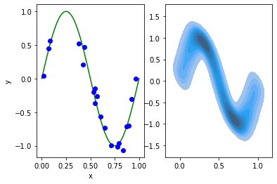

```python
np.random.seed(0)  # set seed for reproducibility

x_data = np.random.uniform(0, 1, size=20)
y_data = np.sin(2 * np.pi * x_data) + np.random.normal(0, 0.1, size=20)

x_true = np.linspace(0, 1, 100)
y_true = np.sin(2 * np.pi * x_true)

# plot data points and true function
fig, ax = plt.subplots(1, 2)
plot(true_points=(x_true, y_true), data_points=(x_data, y_data), ax=ax[0])
# plot kde of data points
_x_data_kde = np.linspace(0, 1, 10000)
_y_data_kde = np.sin(2 * np.pi * _x_data_kde) + np.random.normal(0, 0.1, size=10000)
sns.kdeplot(x=_x_data_kde, y=_y_data_kde, ax=ax[1], shade=True)
plt.show()
```

Now its time to train our model. We'll split the data into training and testing sets.

```python
x_train = x_data[:10]
y_train = y_data[:10]
x_test = x_data[10:]
y_test = y_data[10:]
```

Training the model is easy. There are faster methods in the one-dimensional case, but I'm going to use backpropagation to illustrate the overfitting problem. If you aren't familiar with backpropagation, it treats the backwards propagation of error as a linear algebra problem solved locally at each node in the computation graph. We're fortunate to have a simple model: a linear combination of the exponented values combined with some loss function (e.g. MSE).

$$f(x) = \vec{w} \cdot \vec{x}$$ $$\mathcal{L}(f(x), y) = (f(x) - y)^2$$

Now we train by finding the vector $\vec{w}$ that minimizes the loss function $\mathcal{L}$. Formally, this is

$$\min_{\vec{w}} (\vec{w} \cdot \vec{x} - y)^2$$

Going backwards, we derive our parameter gradients:

$$d\mathcal{L} = 1 $$ $$de = 2 (f(x) - y) \mathcal{L}$$ $$df(x) = de$$ $$d\vec{w} = \vec{x}^T \cdot df(x)$$

Just to stay consistant with deep learning conventions, we'll run an iterative $\eta$-weighted update step instead of moving the parameters all at once. In code this becomes:

```python
def backprop(xs, y_true, w, lr=0.01):

    # build power-bases of xs
    X = np.stack([xs**i for i in range(w.shape[0])], axis=1)  # [n_samples, order]

    # forward pass
    y_pred = X @ w  # [n_samples, order] x [order, 1] = [n_samples]
    err = y_pred - y_true  # [n_samples]
    loss = np.sum(err**2)  # []

    # compute gradient
    dloss = 1  # []
    derr = 2 * err * dloss  # [n_samples]
    dy_pred = derr  # [n_samples]
    dw = X.T @ dy_pred  # [order, n_samples] x [n_samples] = [order]

    # update weights
    w = w - lr * dw

    return w, loss
```

Let's run a few iterations of the update step. If it's working, we should see the weights begin to converge on the true function.

```
Epoch: 10	Loss:  2.266	Val. Loss:  2.337
Epoch: 20	Loss:  2.149	Val. Loss:  2.114
Epoch: 30	Loss:  2.039	Val. Loss:  1.927
Epoch: 40	Loss:  1.935	Val. Loss:  1.758
Epoch: 50	Loss:  1.836	Val. Loss:  1.607
Epoch: 60	Loss:  1.743	Val. Loss:  1.471
Epoch: 70	Loss:  1.655	Val. Loss:  1.349
Epoch: 80	Loss:  1.572	Val. Loss:  1.240
Epoch: 90	Loss:  1.493	Val. Loss:  1.144
Epoch: 100	Loss:  1.419	Val. Loss:  1.060
```

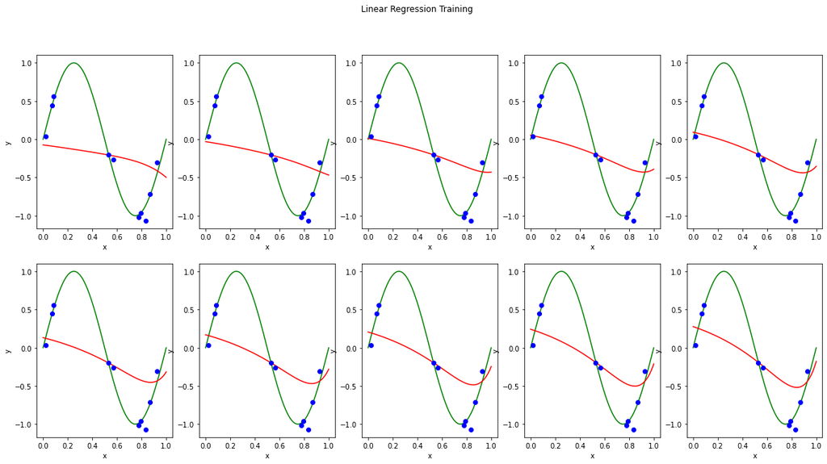

```python
def train_loop(w_init, lr=0.01, n_epochs=100, quiet=False):

     xs = np.linspace(0, 1, 100)
     w = w_init

     if not quiet:
          fig, ax = plt.subplots(2, 5, figsize=(20, 10))
     for i in range(1, 101):

          w, loss = backprop(x_train, y_train, w, lr=lr)

          if i % 10 == 0:

               y_pred = model_matmul(xs, w)
               _, val_loss = backprop(x_test, y_test, w)

               if not quiet:
                    print(f'Epoch: %d\tLoss: %6.3f\tVal. Loss: %6.3f\t' % (i, loss, val_loss))
                    n = i//10 - 1
                    plot(true_points=(x_true, y_true),
                         pred_points=(xs, y_pred),
                         data_points=(x_test, y_test),
                         ax=ax[n//5, n%5])

     if not quiet:
          plt.suptitle('Linear Regression Training')
          plt.show()

     return w

np.random.seed(0)  # set seed for reproducibility
w = np.random.normal(0, 0.1, size=11)
_ = train_loop(w, lr=0.01)
```

Everything looks good! Now let's crank up the linear model order and see what happens.

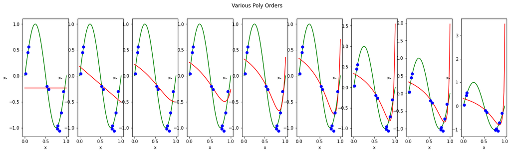

```python
orders = [0, 1, 6, 9, 16, 23, 47, 93, 127]
fig, ax = plt.subplots(1, len(orders), figsize=(20, 5))
xs = np.linspace(0, 1, 100)

for i, order in enumerate(orders):
    np.random.seed(0)  # set seed for reproducibility
    w_init = np.random.normal(0, 0.1, size=(order+1))
    w_fin = train_loop(w_init, lr=0.01/(1+0.001*order), quiet=True)
    plot(true_points=(x_true, y_true),
         pred_points=(xs, model_matmul(xs, w_fin)),
         data_points=(x_test, y_test),
         ax=ax[i])

fig.suptitle('Various Poly Orders')
plt.show()
```

Note that as we increase the order, the model becomes more complex. When pitted up against simple linear regression, the model started overfitting. What can we do to prevent this?

Regularization to the rescue! We'll add a small amount of L2 regularization to our loss function to reduce the overfitting. It goes like this:

$$\mathcal{L}(f(x), y) = (f(x) - y)^2 + \lambda \sum_{i=1}^n w_i^2$$

Backpropagation now includes the additional term:

$$d\vec{w} = \vec{x}^T \cdot df(x) + \underbrace{2 \lambda \vec{w}}_{\text{L2 loss penalty}}$$

In code, this becomes:

```python
def backprop_L2(xs, y_true, w, lambda_L2=0.0, lr=0.01):

    # build power-bases of xs
    X = np.stack([xs**i for i in range(w.shape[0])], axis=1)  # [n_samples, order]

    # forward pass
    y_pred = X @ w  # [n_samples, order] x [order, 1] = [n_samples]
    err = y_pred - y_true  # [n_samples]
    loss = np.sum(err**2)  # []

    # compute gradient
    dloss = 1  # []
    derr = 2 * err * dloss  # [n_samples]
    dy_pred = derr  # [n_samples]
    dw = X.T @ dy_pred  # [order, n_samples] x [n_samples] = [order]
    dw = dw + 2 * lambda_L2 * w  # L2 regularization

    # update weights
    w = w - lr * dw

    return w, loss
```

```
Epoch: 10	Loss:  6.302	Val. Loss:  7.193
Epoch: 20	Loss:  5.250	Val. Loss:  6.005
Epoch: 30	Loss:  4.697	Val. Loss:  5.432
Epoch: 40	Loss:  4.237	Val. Loss:  5.015
Epoch: 50	Loss:  3.836	Val. Loss:  4.680
Epoch: 60	Loss:  3.483	Val. Loss:  4.405
Epoch: 70	Loss:  3.174	Val. Loss:  4.177
Epoch: 80	Loss:  2.902	Val. Loss:  3.986
Epoch: 90	Loss:  2.661	Val. Loss:  3.825
Epoch: 100	Loss:  2.449	Val. Loss:  3.688
```

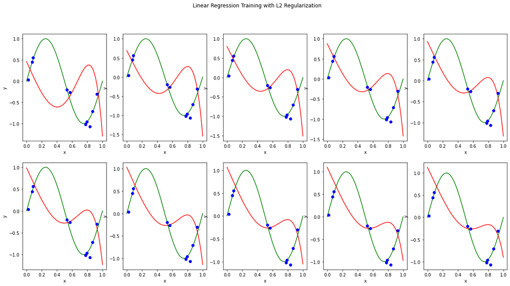

```python
def train_loop(w_init, lr=0.01, lambda_L2=0.0, n_epochs=100, quiet=False):
     xs = np.linspace(0, 1, 100)
     w = w_init
     n = 0

     if not quiet:
          fig, ax = plt.subplots(2, 5, figsize=(20, 10))
     for i in range(1, n_epochs+1):

          w, loss = backprop_L2(x_train, y_train, w, lambda_L2=lambda_L2, lr=lr)

          if i % (n_epochs//10) == 0:

               y_pred = model_matmul(xs, w)
               _, val_loss = backprop_L2(x_test, y_test, w, lambda_L2=0.0)

               if not quiet:
                    print(f'Epoch: %d\tLoss: %6.3f\tVal. Loss: %6.3f\t' % (i, loss, val_loss))
                    plot(true_points=(x_true, y_true),
                         pred_points=(xs, y_pred),
                         data_points=(x_test, y_test),
                         ax=ax[n//5, n%5])
                    n += 1

     if not quiet:
          plt.suptitle('Linear Regression Training with L2 Regularization')
          plt.show()

     return w

np.random.seed(0)  # set seed for reproducibility
w = np.random.normal(0, 5, size=9)
_ = train_loop(w, lr=0.02, lambda_L2=0.1)
```

Good. Okay, let's compare various combinations of poly order with and without regularization. Then we'll make some conclusions on the L2 approach to combat overfitting.

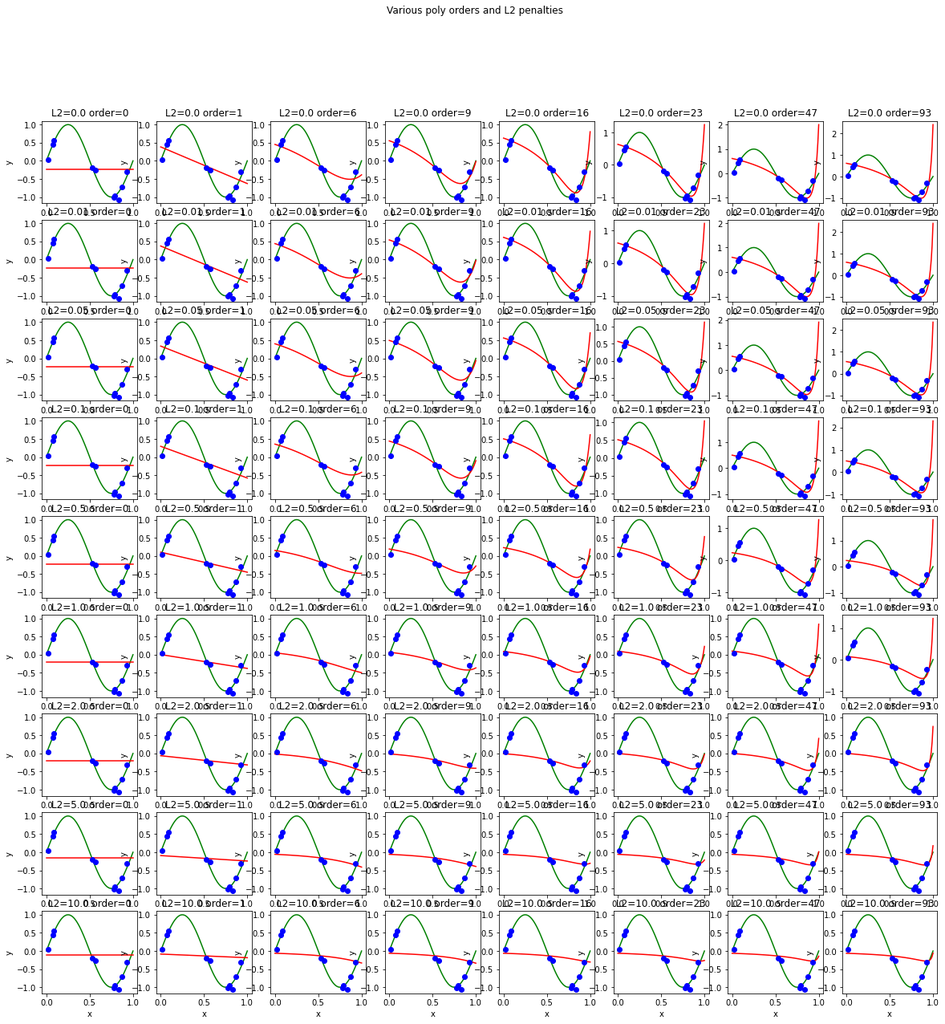

```python
orders = [0, 1, 6, 9, 16, 23, 47, 93]
lambda_L2 = [0.0, 0.01, 0.05, 0.1, 0.5, 1.0, 2.0, 5.0, 10.0]

fig, ax = plt.subplots(len(lambda_L2), len(orders), figsize=(20, 20))

for i, l2 in enumerate(lambda_L2):
    for j, order in enumerate(orders):
        np.random.seed(0)  # set seed for reproducibility
        w_init = np.random.normal(0, 0.1, size=(order+1))
        w_fin = train_loop(w_init,  lr=0.02, lambda_L2=l2, quiet=True)

        plot(true_points=(x_true, y_true),
             pred_points=(xs, model_matmul(xs, w_fin)),
             data_points=(x_test, y_test),
             ax=ax[i,j])
        ax[i,j].title.set_text(f'L2={l2} order={order}')

fig.suptitle('Various poly orders and L2 penalties')
plt.show()
```

Now let's do some qunatitative analysis. Look at the converging weights for the various orders with an without regularization:

```
Results for lambda_L2=0.0
```

|  | M = 0 | M = 1 | M = 6 | M = 9 | M = 16 | M = 23 | M = 47 | M = 93 |
| --- | --- | --- | --- | --- | --- | --- | --- | --- |
| w_0 | -0.231592 | 0.383946 | 0.451798 | 0.554775 | 0.626970 | 0.631668 | 0.614110 | 0.614178 |
| w_1 | 0.000000 | -1.012298 | -0.813740 | -0.845509 | -0.807546 | -0.789180 | -0.764531 | -0.764077 |
| w_2 | 0.000000 | 0.000000 | -0.698745 | -0.828729 | -0.873127 | -0.863600 | -0.831517 | -0.831236 |
| w_3 | 0.000000 | 0.000000 | -0.205091 | -0.400933 | -0.526576 | -0.532125 | -0.506861 | -0.506838 |
| w_4 | 0.000000 | 0.000000 | 0.137173 | -0.100272 | -0.292319 | -0.313132 | -0.299889 | -0.300068 |
| ... | ... | ... | ... | ... | ... | ... | ... | ... |
| w_91 | 0.000000 | 0.000000 | 0.000000 | 0.000000 | 0.000000 | 0.000000 | 0.000000 | 0.131540 |
| w_92 | 0.000000 | 0.000000 | 0.000000 | 0.000000 | 0.000000 | 0.000000 | 0.000000 | 0.029785 |
| w_93 | 0.000000 | 0.000000 | 0.000000 | 0.000000 | 0.000000 | 0.000000 | 0.000000 | 0.106296 |
| abs sum | 0.231592 | 1.396244 | 3.048557 | 4.535315 | 6.488994 | 7.129568 | 8.860466 | 12.118300 |
| abs mean | 0.231592 | 0.698122 | 0.435508 | 0.453531 | 0.381706 | 0.297065 | 0.184593 | 0.128918 |

96 rows × 8 columns

```
Results for lambda_L2=0.05
```

|  | M = 0 | M = 1 | M = 6 | M = 9 | M = 16 | M = 23 | M = 47 | M = 93 |
| --- | --- | --- | --- | --- | --- | --- | --- | --- |
| w_0 | -0.23044 | 0.338691 | 0.402107 | 0.495026 | 0.562539 | 0.568147 | 0.553851 | 0.553765 |
| w_1 | 0.00000 | -0.939155 | -0.741123 | -0.771563 | -0.740826 | -0.724465 | -0.702466 | -0.701770 |
| w_2 | 0.00000 | 0.000000 | -0.643342 | -0.762507 | -0.807156 | -0.799845 | -0.772130 | -0.771506 |
| w_3 | 0.00000 | 0.000000 | -0.206262 | -0.384445 | -0.501760 | -0.508774 | -0.487752 | -0.487436 |
| w_4 | 0.00000 | 0.000000 | 0.108379 | -0.106850 | -0.282949 | -0.304216 | -0.294320 | -0.294331 |
| ... | ... | ... | ... | ... | ... | ... | ... | ... |
| w_91 | 0.00000 | 0.000000 | 0.000000 | 0.000000 | 0.000000 | 0.000000 | 0.000000 | 0.109010 |
| w_92 | 0.00000 | 0.000000 | 0.000000 | 0.000000 | 0.000000 | 0.000000 | 0.000000 | 0.025668 |
| w_93 | 0.00000 | 0.000000 | 0.000000 | 0.000000 | 0.000000 | 0.000000 | 0.000000 | 0.088251 |
| abs sum | 0.23044 | 1.277846 | 2.777711 | 4.153107 | 5.973123 | 6.552749 | 8.018477 | 10.652182 |
| abs mean | 0.23044 | 0.638923 | 0.396816 | 0.415311 | 0.351360 | 0.273031 | 0.167052 | 0.113321 |

96 rows × 8 columns

```
Results for lambda_L2=0.1
```

|  | M = 0 | M = 1 | M = 6 | M = 9 | M = 16 | M = 23 | M = 47 | M = 93 |
| --- | --- | --- | --- | --- | --- | --- | --- | --- |
| w_0 | -0.229299 | 0.298701 | 0.358543 | 0.442504 | 0.505692 | 0.512035 | 0.500541 | 0.500360 |
| w_1 | 0.000000 | -0.874363 | -0.678051 | -0.707208 | -0.682607 | -0.668072 | -0.648421 | -0.647550 |
| w_2 | 0.000000 | 0.000000 | -0.594576 | -0.704030 | -0.748618 | -0.743259 | -0.719366 | -0.718504 |
| w_3 | 0.000000 | 0.000000 | -0.205803 | -0.368236 | -0.478008 | -0.486244 | -0.468908 | -0.468399 |
| w_4 | 0.000000 | 0.000000 | 0.084187 | -0.111283 | -0.273234 | -0.294774 | -0.287760 | -0.287673 |
| ... | ... | ... | ... | ... | ... | ... | ... | ... |
| w_91 | 0.000000 | 0.000000 | 0.000000 | 0.000000 | 0.000000 | 0.000000 | 0.000000 | 0.090501 |
| w_92 | 0.000000 | 0.000000 | 0.000000 | 0.000000 | 0.000000 | 0.000000 | 0.000000 | 0.022260 |
| w_93 | 0.000000 | 0.000000 | 0.000000 | 0.000000 | 0.000000 | 0.000000 | 0.000000 | 0.073422 |
| abs sum | 0.229299 | 1.173064 | 2.538353 | 3.814889 | 5.515162 | 6.082663 | 7.313230 | 9.450002 |
| abs mean | 0.229299 | 0.586532 | 0.362622 | 0.381489 | 0.324421 | 0.253444 | 0.152359 | 0.100532 |

96 rows × 8 columns

```
Results for lambda_L2=1.0
```

|  | M = 0 | M = 1 | M = 6 | M = 9 | M = 16 | M = 23 | M = 47 | M = 93 |
| --- | --- | --- | --- | --- | --- | --- | --- | --- |
| w_0 | -0.210538 | 0.003131 | 0.050081 | 0.066962 | 0.088549 | 0.095486 | 0.099204 | 0.099569 |
| w_1 | 0.000000 | -0.381871 | -0.255695 | -0.269463 | -0.277091 | -0.276953 | -0.274493 | -0.273932 |
| w_2 | 0.000000 | 0.000000 | -0.241408 | -0.273167 | -0.302047 | -0.308511 | -0.309654 | -0.309431 |
| w_3 | 0.000000 | 0.000000 | -0.142424 | -0.184495 | -0.227974 | -0.239875 | -0.244989 | -0.245266 |
| w_4 | 0.000000 | 0.000000 | -0.042228 | -0.089930 | -0.143063 | -0.159159 | -0.167913 | -0.168706 |
| ... | ... | ... | ... | ... | ... | ... | ... | ... |
| w_91 | 0.000000 | 0.000000 | 0.000000 | 0.000000 | 0.000000 | 0.000000 | 0.000000 | 0.007342 |
| w_92 | 0.000000 | 0.000000 | 0.000000 | 0.000000 | 0.000000 | 0.000000 | 0.000000 | 0.005440 |
| w_93 | 0.000000 | 0.000000 | 0.000000 | 0.000000 | 0.000000 | 0.000000 | 0.000000 | 0.006551 |
| abs sum | 0.210538 | 0.385002 | 0.866922 | 1.299949 | 2.036679 | 2.456913 | 3.177809 | 3.648683 |
| abs mean | 0.210538 | 0.192501 | 0.123846 | 0.129995 | 0.119805 | 0.102371 | 0.066204 | 0.038816 |

96 rows × 8 columns

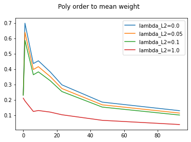

```python
orders = [0, 1, 6, 9, 16, 23, 47, 93]
lambda_L2 = [0.0, 0.05, 0.1, 1.0]

means = np.zeros((len(lambda_L2), len(orders)))

for i, l2 in enumerate(lambda_L2):

    W = np.zeros((max(orders)+3, len(orders)))

    for j, order in enumerate(orders):
        np.random.seed(0)  # set seed for reproducibility
        w_init = np.random.normal(0, 0.1, size=(order+1))
        w_fin = train_loop(w_init, lr=0.02, lambda_L2=l2, quiet=True)
        W[:order+1, j] = w_fin

    sum = W[-2] = np.sum(np.abs(W[:-2]), axis=0)
    mean = W[-1] = sum / (np.array(orders)+1)
    means[i] = mean

    df = pd.DataFrame(W,
        columns=['M = %d' % order for order in orders],
        index=['w_%d' % i for i in range(max(orders)+1)] + ['abs sum', 'abs mean'])

    print(f'Results for lambda_L2={l2}')
    display.display(df)

for i, l2 in enumerate(lambda_L2):
    plt.plot(orders, means[i])
plt.legend([f'lambda_L2={l2}' for l2 in lambda_L2])
plt.suptitle('Poly order to mean weight')
plt.show()
```

Notice that while weights are decreasing with increasing order, they loose sensitivity to order with increasing regularization weight (it might approach a powerlaw!). Again, we see the regularization term in action.

I'm actually curious to see if it really is a powerlaw:

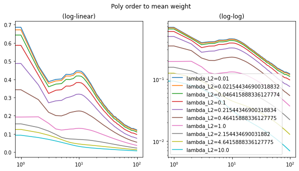

```python
orders = list(range(100))
lambda_L2 = 10 ** np.linspace(-2,1,10)

means = np.zeros((len(lambda_L2), len(orders)))

for i, l2 in enumerate(lambda_L2):

    W = np.zeros((max(orders)+3, len(orders)))

    for j, order in enumerate(orders):
        np.random.seed(0)  # set seed for reproducibility
        w_init = np.random.normal(0, 0.1, size=(order+1))
        w_fin = train_loop(w_init, lr=0.02, lambda_L2=l2, quiet=True)
        W[:order+1, j] = w_fin

    sum = W[-2] = np.sum(np.abs(W[:-2]), axis=0)
    mean = W[-1] = sum / (np.array(orders)+1)
    means[i] = mean

fig, ax = plt.subplots(1, 2, figsize=(10,5))

for i, l2 in enumerate(lambda_L2):
    ax[0].plot(orders, means[i])
    ax[1].plot(orders, means[i])
plt.legend([f'lambda_L2={l2}' for l2 in lambda_L2])
ax[0].set_xscale('log')
ax[1].set_xscale('log')
ax[1].set_yscale('log')
ax[0].set_title('(log-linear)')
ax[1].set_title('(log-log)')
plt.suptitle('Poly order to mean weight')

plt.show()
```

No. It doesn't look like one from superficial inspection. Although something interesting appears to be occuring at `order=5`.

Let's consider train vs. test error across the various orders with and without regularization:

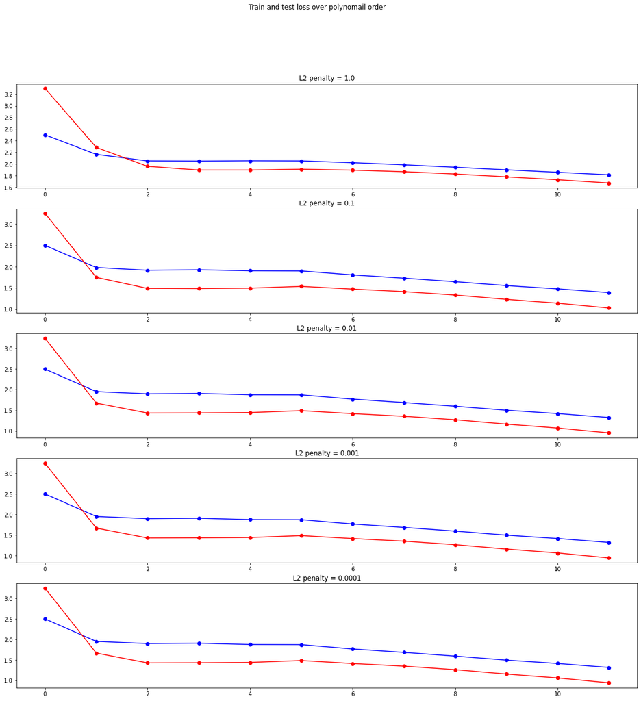

```python
def loss(xs, y_true, w):
    X = np.stack([xs**i for i in range(w.shape[0])], axis=1)  # [n_samples, order]
    y_pred = X @ w  # [n_samples, order] x [order, 1] = [n_samples]
    err = y_pred - y_true  # [n_samples]
    return np.sum(err**2)  # []

orders = list(range(12))
lambda_L2 = 10.**-np.arange(5)

fig, ax = plt.subplots(len(lambda_L2), 1, figsize=(20, 20))

for i, l2 in enumerate(lambda_L2):
    loss_train = []
    loss_test = []

    for j, order in enumerate(orders):
        np.random.seed(0)  # set seed for reproducibility
        w_init = np.random.normal(0, 0.1, size=(order+1))
        w_fin = train_loop(w_init, lambda_L2=l2, quiet=True)
        loss_train.append(loss(x_train, y_train, w_fin))
        loss_test.append(loss(x_test, y_test, w_fin))

    ax[i].title.set_text(f'L2 penalty = {l2}')
    ax[i].plot(orders, loss_train, 'bo-', label='Training')
    ax[i].plot(orders, loss_test, 'ro-', label='Validation')

fig.suptitle('Train and test loss over polynomail order')
plt.show()
```

It's hard to make meaningful conclusion from this data, but I hope you found some yourself. That wraps up a fun adventure! I hope you enjoyed this tutorial. If you have any questions, please let me know. I'm also attaching some references below for further reading on other applications of regularization:

## References

[GROKKING: GENERALIZATION BEYOND OVERFITTING ON SMALL ALGORITHMIC DATASETS](https://mathai-iclr.github.io/papers/papers/MATHAI_29_paper.pdf)

[Batch Normalization: Accelerating Deep Network Training by Reducing Internal Covariate Shift](https://arxiv.org/abs/1502.03167)

[Generalization Error Analysis of Neural networks with Gradient Based Regularization](https://arxiv.org/abs/2107.02797)